# Reproduce Münch et al. (2017) figures

Thomas Münch

2024-02-26

## Overview

This vignette reproduces the figures shown in the publication of Münch et al. (2017).

The data processing and plotting is implemented in the internal function `produceTC17Figures()`; to inspect the source code, type `TrenchR:::produceTC17Figures` in your R console, or download the package’s source version.

Note that during development of `TrenchR`, the underlying trench isotope source data as used for the publication of Münch et al. (2017) has been updated from unrounded data to rounded data to reflect the isotope measurement uncertainty. This change results in small apparent differences for Figures 5 and 7 between the published versions and the versions reproduced here; in any case, however, it does not impact any conclusions drawn in the publication.

## Figure 1

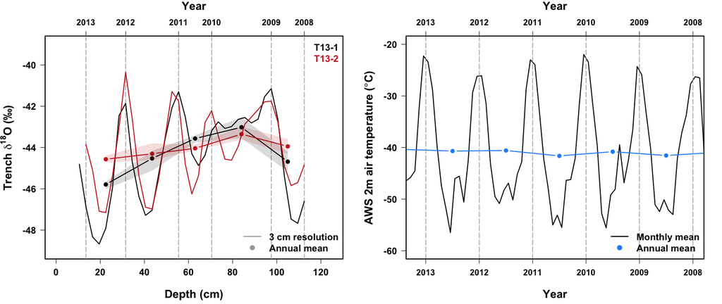

```r
TrenchR:::produceTC17Figures("f1")
```

## Figure 2

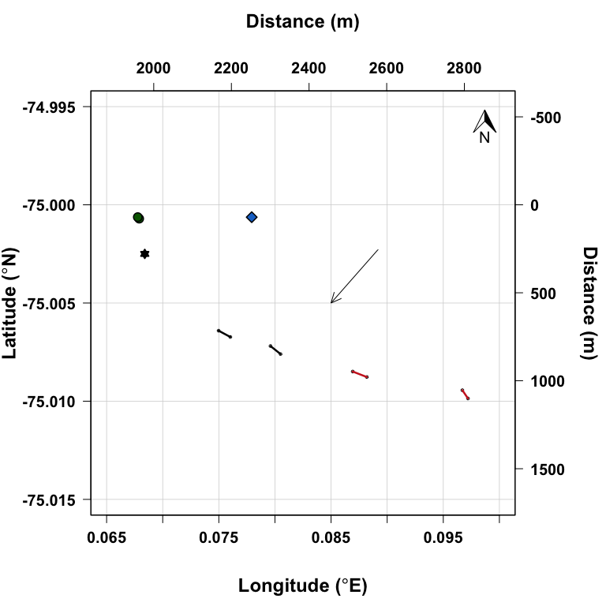

```r
TrenchR:::produceTC17Figures("f2")
```

## Figure 3

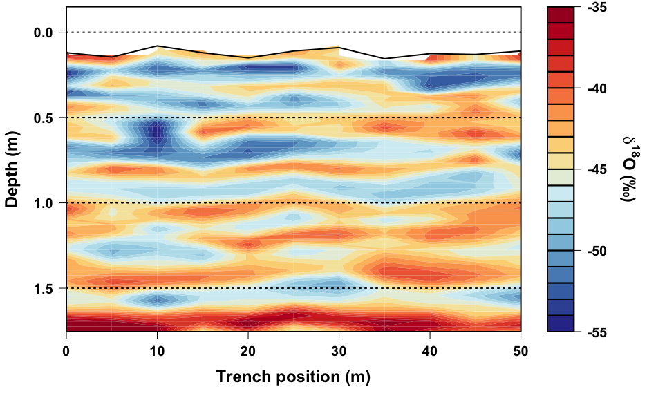

```r
TrenchR:::produceTC17Figures("f3a")
```

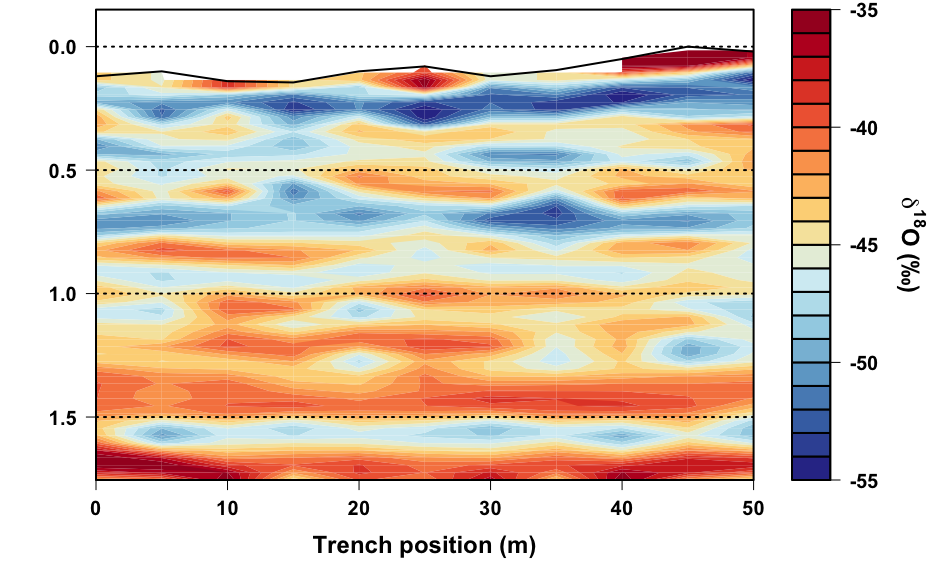

```r
TrenchR:::produceTC17Figures("f3b")
```

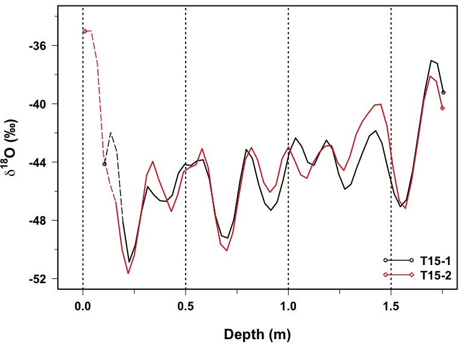

```r
TrenchR:::produceTC17Figures("f3c")
```

## Figure 4

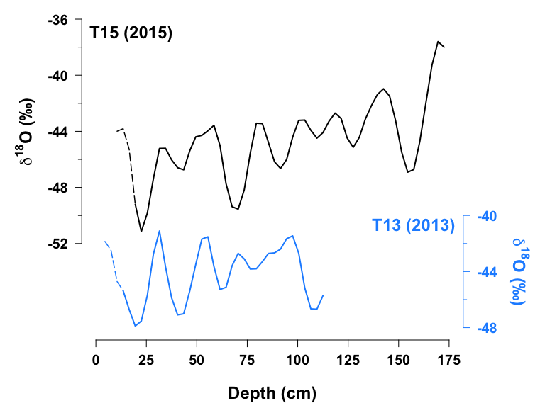

```r
TrenchR:::produceTC17Figures("f4")
```

## Figure 5

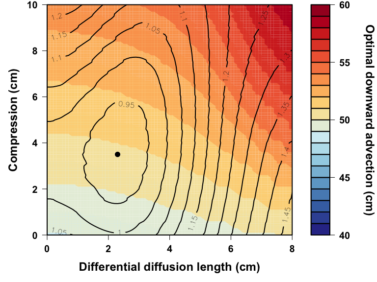

```r
TrenchR:::produceTC17Figures("f5")
```

## Figure 6

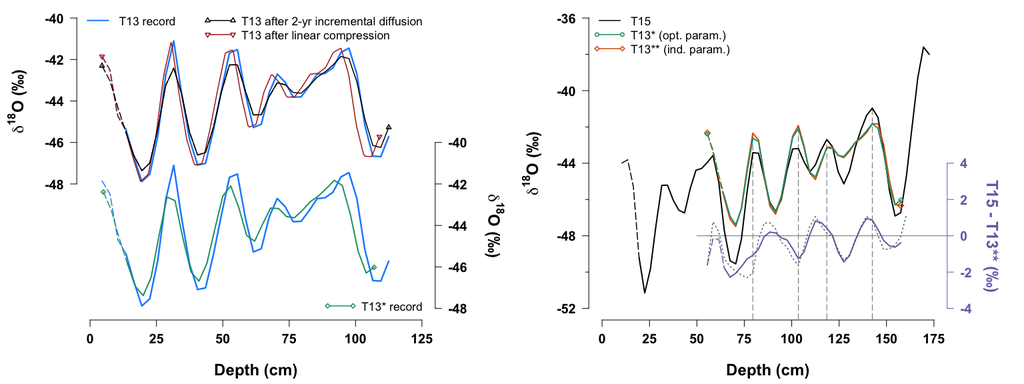

```r
TrenchR:::produceTC17Figures("f6")
```

## Figure 7

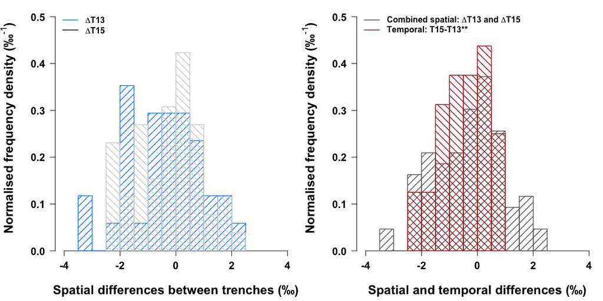

```r
TrenchR:::produceTC17Figures("f7")
```

## References

Münch, T., Kipfstuhl, S., Freitag, J., Meyer, H., and Laepple, T.: Constraints on post-depositional isotope modifications in East Antarctic firn from analysing temporal changes of isotope profiles, *The Cryosphere*, **11**(5), 2175-2188, doi: 10.5194/tc-11-2175-2017, 2017.